# Communicating Data Findings of Ford Go Bikes

## Investigation Overview

> In this presentation, I will be investigating factors from a history of Ford Go Bikes rides. I will be using trip data as well as demographics to find how who uses the bikes and for what.

## Dataset Overview

> The dataset is from a history of all Ford Go Bike rides in California. The data includes trip data like distance and duration, demographics such as gender and age and much more.

## The Relationship of Gender and Age by Bike Ride Frequency

> The relationship between gender and age by bike ride frequency is right skewed. There is a high incline towards the younger ages and a slower, more steady decline when reaching the older ages. Females have one peak at around age 30 where they are 2 proportions higher than males. Males have two peaks at around ages 25 and 35. It also looks like males are more likely to go on bike rides into their older years than females.

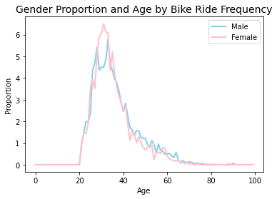

```python
hide_code_in_slideshow()
#Creating new dataframe:
range_df = pd.DataFrame()
range_df['member_age'] = range(100) # age limit of 100
male = range_df.member_age.apply(lambda x:len(df[(df.member_age == x) & (df.member_gender == 'Male')]))
female = range_df.member_age.apply(lambda x:len(df[(df.member_age == x) & (df.member_gender == 'Female')]))

#Correcting proportions:
female_prop = female / sum(female) * 100
male_prop = male / sum(male) * 100

#Plotting:
plt.plot( range_df, male_prop, color='skyblue', linewidth=2)
plt.plot( range_df, female_prop, color='pink', linewidth=2)
plt.legend(['Male','Female'])
plt.xlabel('Age')
plt.ylabel('Proportion')
plt.title('Gender Proportion and Age by Bike Ride Frequency', {'fontsize' : 14});
```

## The Relationship Between Distance and Time

> With a sample of 100, the overall relationship between distance and time seems to be positive with medium correlation. There is more correlation towards the beginning and widens out over time and distance.

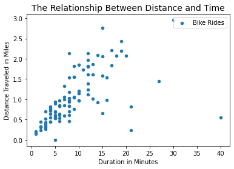

```python
hide_code_in_slideshow()
#Plotting the relationship of distance and time by sample:
df[df['duration_min'] < 50].sample(100).plot.scatter(x='duration_min', y='distance_traveled')
plt.title("The Relationship Between Distance and Time", {'fontsize' : 14})
plt.xlabel("Duration in Minutes")
plt.ylabel("Distance Traveled in Miles")
plt.legend(["Bike Rides"]);
```

## The Relationship of Distance and Time by Age Group

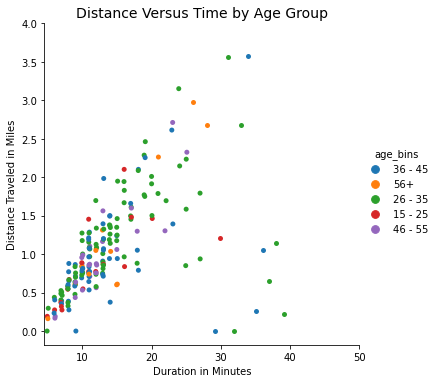

```python
hide_code_in_slideshow()
#Creating age groups:
df['age_bins'] = df['member_age'].apply(lambda x: '15 - 25' if 15<x<=25
                                                  else '26 - 35' if 25<x<=35
                                                  else '36 - 45' if 35<x<=45
                                                  else '46 - 55' if 45<x<=55
                                                  else '56+' if 55<=x
                                                       else x)
#Creating a sample:
sample = df.sample(200)

#Plotting a sample of age groups and their relationship to distance and time:
sns.catplot(data = sample, x='duration_min', y='distance_traveled', hue='age_bins')
plt.ylim(top=4)
plt.xlabel('Duration in Minutes')
plt.ylabel('Distance Traveled in Miles')
plt.title("Distance Versus Time by Age Group", fontsize = 14)
plt.xticks(np.arange(5,50, step=10),['10','20','30','40','50']);
```

## The Relationship of Distance and Time by Gender

> This visual shows a similar trend to the graph with age groups. There is a strong positive relationship towards the beginning, and loses correlation over larger numbers. There are more males riding than females in this sample. The males are also riding for longer times and distances than females.

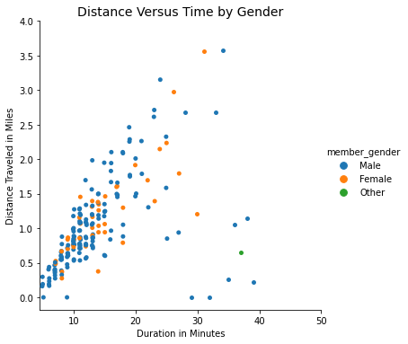

```python
hide_code_in_slideshow()
#Plotting a sample of genders and their relationship to distance and time:
sns.catplot(data = sample, x='duration_min', y='distance_traveled', hue='member_gender')

plt.ylim(top=4)
plt.xlabel('Duration in Minutes')
plt.ylabel('Distance Traveled in Miles')
plt.title("Distance Versus Time by Gender", fontsize = 14)
plt.xticks(np.arange(5,50, step=10),['10','20','30','40','50']);
```